# quarto vignettes

pkgdown effectively uses quarto only to generate HTML and then supplies its own CSS and JS. This means that when quarto introduces new features, pkgdown may lag behind in their support. If you’re trying out something that doesn’t work (and isn’t mentioned explicitly below), please [file an issue](https://github.com/r-lib/pkgdown/issues) so we can look into it.

## Operation

pkgdown turns your articles directory into a quarto project by temporarily adding a `_quarto.yml` to your articles. You can also add your own if you want to control options for all quarto articles. If you do so, and you have a mix of `.qmd` and `.Rmd` files, you’ll need to include the following yaml so that RMarkdown can continue to handle the .Rmd files:

```yaml
project:
  render: ['*.qmd']
```

### GitHub Actions

The `setup-r-dependencies` action will [automatically](https://github.com/r-lib/actions/tree/v2-branch/setup-r-dependencies#usage) install Quarto in your GitHub Actions if a .qmd file is present in your repository (see the `install-quarto` parameter for more details).

## Limitations

- Callouts are not currently supported (https://github.com/quarto-dev/quarto-cli/issues/9963).
- pkgdown assumes that you’re using [quarto vignette style](https://quarto-dev.github.io/quarto-r/articles/hello.html), or more generally an html format with [`minimal: true`](https://quarto.org/docs/output-formats/html-basics.html#minimal-html). Specifically, only HTML vignettes are currently supported.
- You can’t customise mermaid styles with quarto mermaid themes. If you want to change the colours, you’ll need to provide your own custom CSS as shown in [the quarto docs](https://quarto.org/docs/authoring/diagrams.html#customizing-mermaid).
- pkgdown will pass the `lang` setting on to quarto, but the set of available languages is not perfectly matched. Learn more in https://quarto.org/docs/authoring/language.html, including how to supply your own translations.

## Supported features

The following sections demonstrate a bunch of useful quarto features so that we can make sure that they work.

### Inline formatting

- Small caps
- Here is a footnote reference[^1]

### Code

```r
1 + 1
```

```
#> [1] 2
```

```r
2 + 2
```

```
#> [1] 4
```

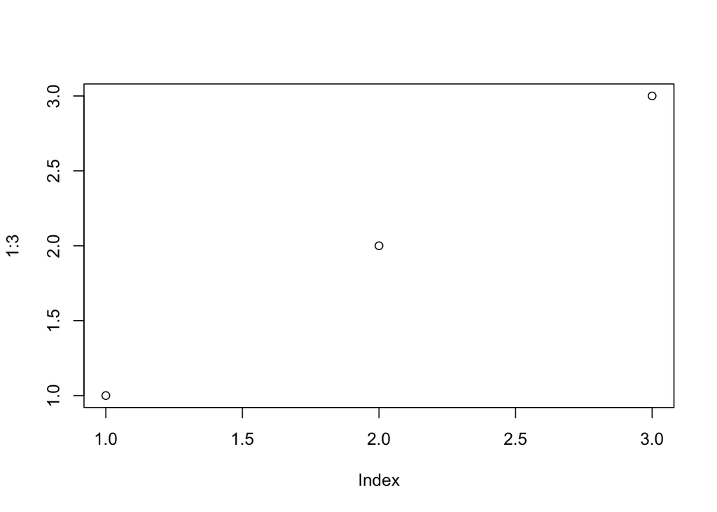

```r
plot(1:3)
```

### Figures

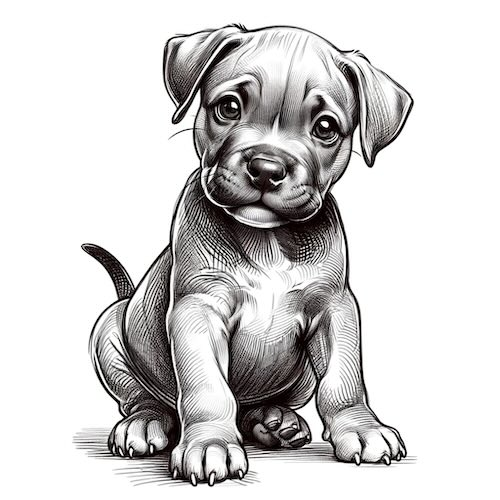

(a) A sketch of a pitbull puppy

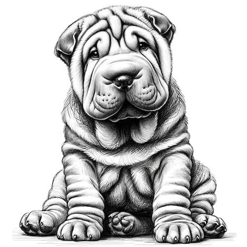

(b) A sketch of a sharpei puppy

Figure 1: Cute puppies

### Equations

$$\frac{\partial \mathrm C}{ \partial \mathrm t } + \frac{1}{2}\sigma^{2} \mathrm S^{2}
\frac{\partial^{2} \mathrm C}{\partial \mathrm C^2}
+ \mathrm r \mathrm S \frac{\partial \mathrm C}{\partial \mathrm S}\ =
\mathrm r \mathrm C
\qquad(1)$$

### Cross references

See Figure 1 for two cute puppies.

Black-Scholes (Equation 1) is a mathematical model that seeks to explain the behavior of financial derivatives, most commonly options.

## To do

- Code annotations
- Tabsets
- Citations
- Task/to do lists
- Figures
- Equations
- Cross-references
- Footnotes
- Callouts
[^1]: And here is the footnote.